# Review: Double Integrals

MATH 321 – Mathematical Statistics I

Torin Quinlivan

tquinlivan@knox.edu

Knox College

October 13, 2026

## Iterated Integrals

An iterated integral is evaluated from the inside out:
$$\int_a^b \int_c^d f(x, y) \, dy \, dx = \int_a^b \left[ \int_c^d f(x, y) \, dy \right] dx.$$

- The inner integral is with respect to $y$, so we treat $x$ as a **constant** while we integrate.
- The result of the inner integral is a function of $x$ only, which we then integrate from $a$ to $b$.

The differentials are read from the inside out: the innermost differential ($dy$) goes with the innermost integral sign ($\int_c^d$).

## Fubini’s Theorem

**Theorem (Fubini):** If $f$ is continuous on the rectangle $R = [a, b] \times [c, d]$, then
$$\iint_R f(x, y) \, dA = \int_a^b \int_c^d f(x, y) \, dy \, dx = \int_c^d \int_a^b f(x, y) \, dx \, dy.$$

Over a rectangle, reversing the order of integration is easy: **the bounds just travel with their variable**.

## Example 1: A Rectangular Region

Evaluate $\displaystyle\iint_R 6xy^2 \, dA$, where $R = \{ (x, y) : 0 \le x \le 2, \ 0 \le y \le 1 \}$.

**Integrating $y$ first:**
$$\begin{aligned}
\int_0^2 \int_0^1 6xy^2 \, dy \, dx &= \int_0^2 \Big[ 2xy^3 \Big]_{y=0}^{y=1} \, dx \\
&= \int_0^2 2x \, dx \\
&= \Big[ x^2 \Big]_0^2 = 4.
\end{aligned}$$

## Example 1: A Rectangular Region

Evaluate $\displaystyle\iint_R 6xy^2 \, dA$, where $R = \{ (x, y) : 0 \le x \le 2, \ 0 \le y \le 1 \}$.

**Integrating $x$ first:**
$$\begin{aligned}
\int_0^1 \int_0^2 6xy^2 \, dx \, dy &= \int_0^1 \Big[ 3x^2y^2 \Big]_{x=0}^{x=2} \, dy \\
&= \int_0^1 12y^2 \, dy \\
&= \Big[ 4y^3 \Big]_0^1 = 4. \checkmark
\end{aligned}$$

## A Shortcut for Products

If the region is a rectangle **and** the integrand factors as $f(x, y) = g(x) \, h(y)$, then
$$\int_a^b \int_c^d g(x) \, h(y) \, dy \, dx = \left( \int_a^b g(x) \, dx \right) \left( \int_c^d h(y) \, dy \right).$$

For Example 1:
$$\int_0^2 \int_0^1 6xy^2 \, dy \, dx = \left( \int_0^2 x \, dx \right) \left( \int_0^1 6y^2 \, dy \right) = (2)(2) = 4.$$

**Warning:** This only works when *both* conditions hold. If the bounds depend on $x$ or $y$, the integral does **not** split.

## Rules for Setting Up Bounds

1. The **outer** bounds must be **constants**.
2. The **inner** bounds may depend on the **outer** variable, but never on the inner variable.
3. After evaluating the inner integral, the inner variable should be completely gone.
4. A double integral evaluates to a **number**, never a function of $x$ or $y$.

**Think in slices:** with $dy \, dx$, fix $x$ and draw a **vertical** line through the region. Its bottom and top give the $y$-bounds. With $dx \, dy$, fix $y$ and draw a **horizontal** line. Its left and right ends give the $x$-bounds.

## Example 2: A Triangular Region

Let $f(x, y) = 6y$ for $A = \{ (x,y) : 0 \le y \le x \le 1 \}$ Find $\displaystyle\iint_A f(x, y) \, dA$.

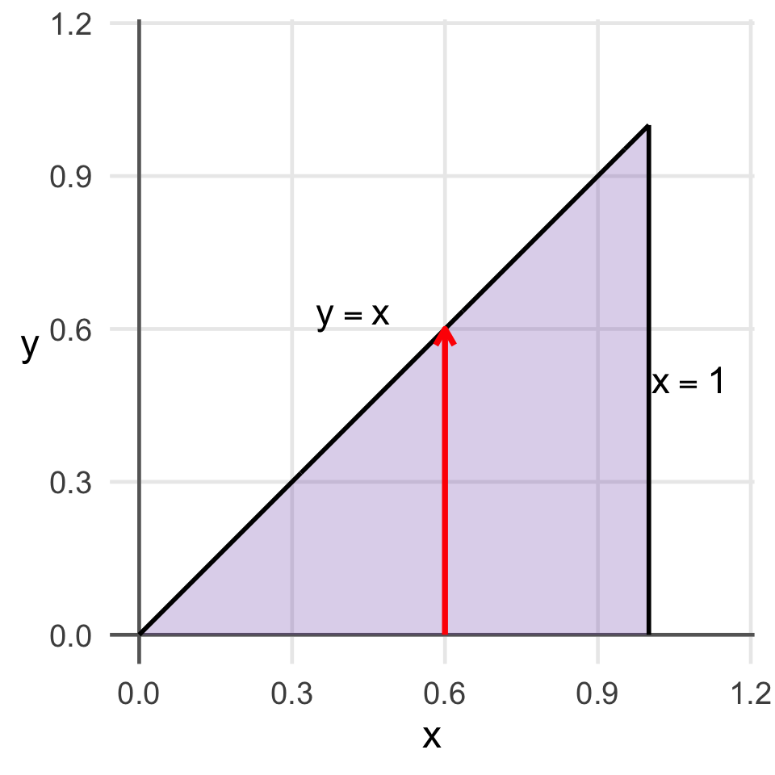

Vertical slice at $x$: $y$ runs from $0$ up to $x$.
$$\begin{aligned}
\int_0^1 \int_0^x 6y \, dy \, dx &= \int_0^1 \Big[ 3y^2 \Big]_{y=0}^{y=x} \, dx \\
&= \int_0^1 3x^2 \, dx \\
&= \Big[ x^3 \Big]_0^1 = 1.
\end{aligned}$$
Since $f \ge 0$ and it integrates to $1$, $f$ is a valid joint density.

## Reversing the Order of Integration

To switch from $dy \, dx$ to $dx \, dy$ (or vice versa):

1. **Read the region** off the current bounds and write it as a set of inequalities.
2. **Sketch the region.** Label each boundary curve and find where the curves intersect.
3. **Find the new outer bounds:** the smallest and largest values the new outer variable takes *anywhere* in the region. These must be constants.
4. **Find the new inner bounds:** fix the outer variable, draw a slice across the region, and see which curves it enters and exits through. Solve those curves for the inner variable.
5. **Check for a split:** if the entry or exit curve changes partway through, break the integral into pieces.

## Example 2: Reversed

Rewrite $\displaystyle\int_0^1 \int_0^x 6y \, dy \, dx$ in the order $dx \, dy$.

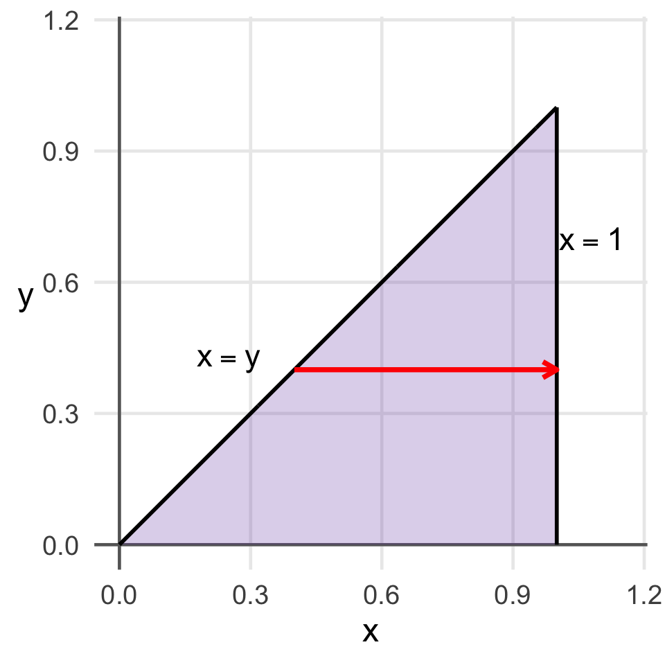

- $y$ ranges over $[0, 1]$ in the region.
- Horizontal slice at $y$: enter at $x = y$, exit at $x = 1$.

$$\begin{aligned}
\int_0^1 \int_y^1 6y \, dx \, dy &= \int_0^1 \Big[ 6xy \Big]_{x=y}^{x=1} \, dy \\
&= \int_0^1 (6y - 6y^2) \, dy \\
&= \Big[ 3y^2 - 2y^3 \Big]_0^1 = 1. \checkmark
\end{aligned}$$

## Example 3: Between Two Curves

Reverse the order of integration and evaluate both ways: $\displaystyle\int_0^1 \int_{x^2}^{x} x \, dy \, dx$.

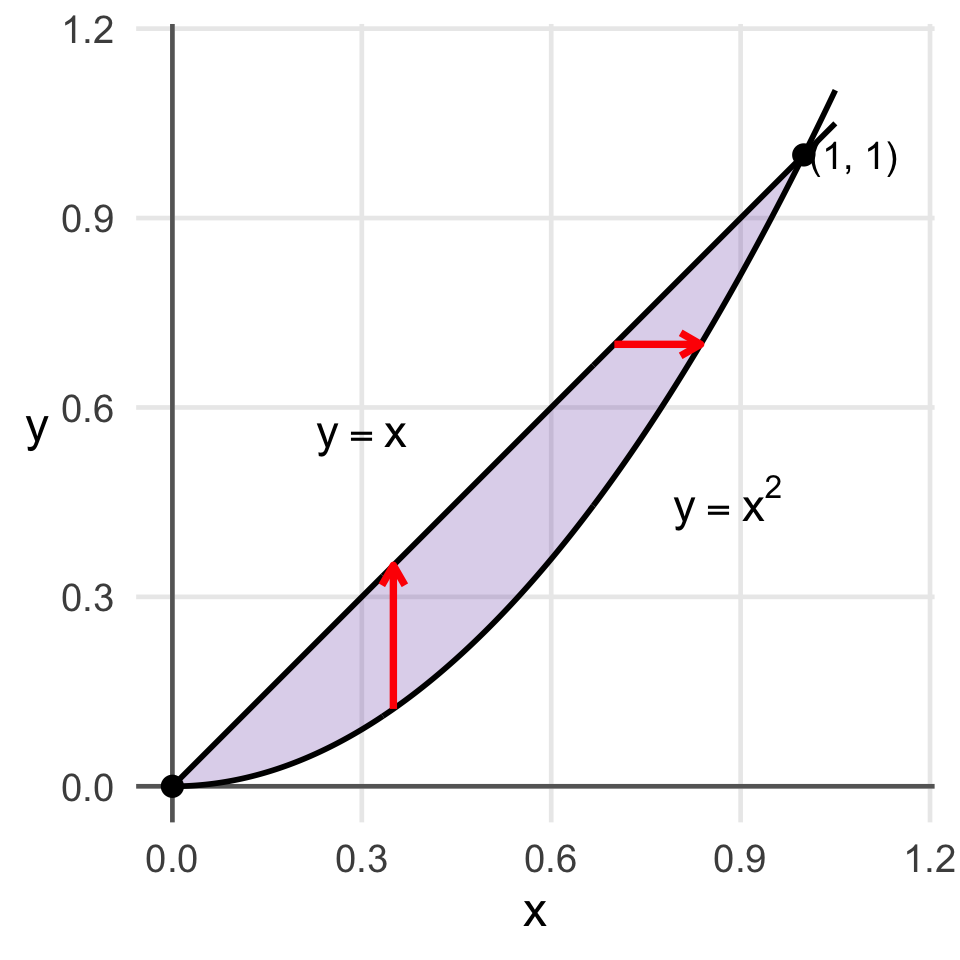

Region: $0 \le x \le 1$, $\ x^2 \le y \le x$. Curves meet at $(0, 0)$ and $(1, 1)$.

Horizontal slice at $y \in [0, 1]$: enter on $x = y$ (line), exit on $x = \sqrt{y}$ (parabola).

$$\int_0^1 \int_{x^2}^{x} x \, dy \, dx = \int_0^1 \int_{y}^{\sqrt{y}} x \, dx \, dy$$

## Example 3: Between Two Curves

**Vertical slices ($dy \, dx$):**
$$\int_0^1 \int_{x^2}^{x} x \, dy \, dx = \int_0^1 x(x - x^2) \, dx = \int_0^1 (x^2 - x^3) \, dx = \frac{1}{3} - \frac{1}{4} = \frac{1}{12}.$$

**Horizontal slices ($dx \, dy$):**
$$\begin{aligned}
\int_0^1 \int_{y}^{\sqrt{y}} x \, dx \, dy &= \int_0^1 \left[ \frac{x^2}{2} \right]_{x=y}^{x=\sqrt{y}} dy \\
&= \frac{1}{2} \int_0^1 (y - y^2) \, dy = \frac{1}{2} \left( \frac{1}{2} - \frac{1}{3} \right) = \frac{1}{12}. \checkmark
\end{aligned}$$

## Why Reverse? Example 4

Evaluate $\displaystyle\int_0^1 \int_y^1 e^{x^2} \, dx \, dy$. Problem: $e^{x^2}$ has no elementary antiderivative!

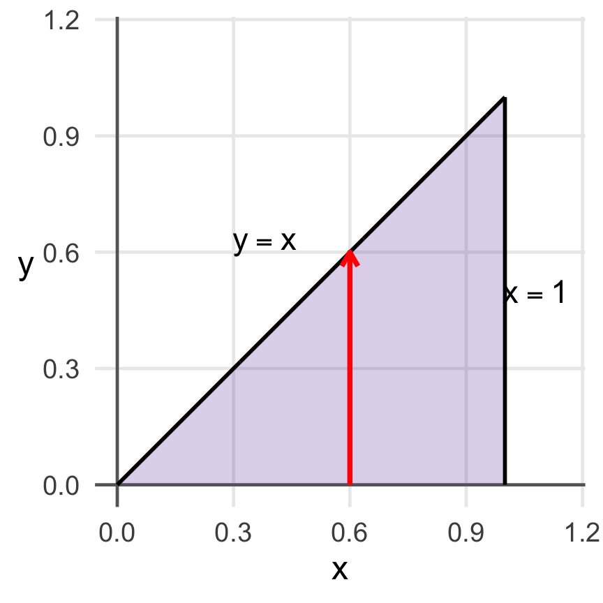

Region: $0 \le y \le 1$, $\ y \le x \le 1$, the same triangle as Example 2! Vertical slice at $x \in [0, 1]$: $y$ runs from $0$ to $x$.

$$\begin{aligned}
\int_0^1 \int_0^x e^{x^2} \, dy \, dx &= \int_0^1 x e^{x^2} \, dx \\
&= \left[ \tfrac{1}{2} e^{x^2} \right]_0^1 = \tfrac{e - 1}{2}.
\end{aligned}$$

## Example 5: When One Order Needs a Split

Let $R$ be the triangle with vertices $(0, 0)$, $(2, 0)$, and $(1, 1)$. Evaluate $\displaystyle\iint_R y \, dA$.

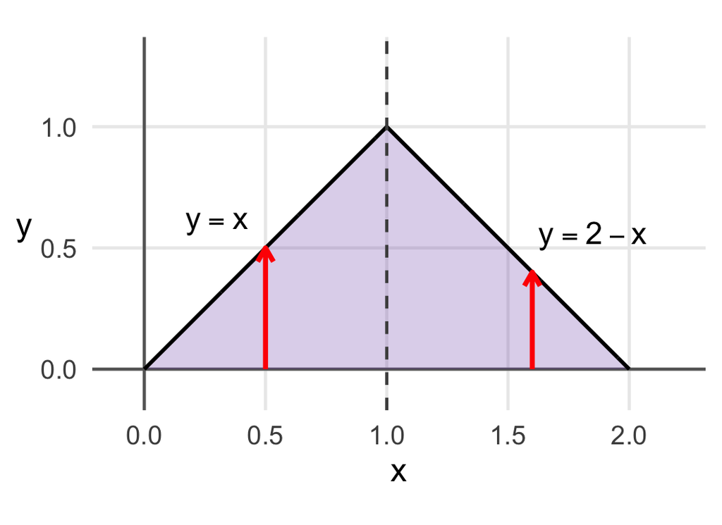

**Vertical slices:** the top curve changes at $x = 1$, so we must split:
$$\begin{aligned}
&\int_0^1 \int_0^x y \, dy \, dx + \int_1^2 \int_0^{2-x} y \, dy \, dx \\
&\quad = \int_0^1 \frac{x^2}{2} \, dx + \int_1^2 \frac{(2-x)^2}{2} \, dx \\
&\quad = \frac{1}{6} + \frac{1}{6} = \frac{1}{3}.
\end{aligned}$$

## Example 5: When One Order Needs a Split

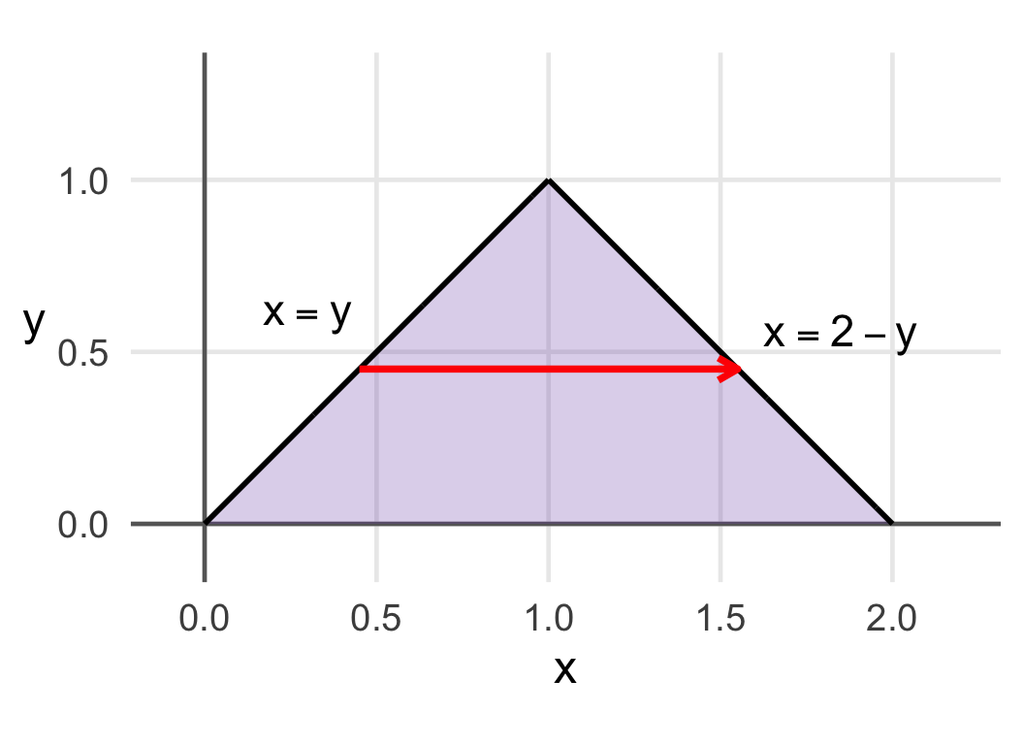

**Horizontal slices:** for every $y \in [0, 1]$, enter on $x = y$ and exit on $x = 2 - y$. No split needed!

$$\begin{aligned}
\int_0^1 \int_y^{2-y} y \, dx \, dy &= \int_0^1 y(2 - 2y) \, dy \\
&= \Big[ y^2 - \tfrac{2}{3}y^3 \Big]_0^1 = \frac{1}{3}. \checkmark
\end{aligned}$$

**Lesson:** Before integrating, check whether one order gives a single integral. Choose that one.

## Common Mistakes

- **Swapping bounds without re-deriving them.** $\displaystyle\int_0^1 \int_0^x f \, dy \, dx \ne \int_0^x \int_0^1 f \, dx \, dy$. The right side isn’t even a number!
- **Variable outer bounds.** If an outer bound contains $x$ or $y$, the setup is wrong.
- **Mismatched differentials.** The order of $dx$ and $dy$ must match the bounds: $\displaystyle\int_0^1 \int_0^x 6y \, dx \, dy$ is wrong if you meant “$y$ from $0$ to $x$.” The inner bounds belong to the inner differential.
- **Missing a split.** If a slice’s entry or exit curve changes, you need more than one integral (or the other order).